# Modul 02: Perbandingan Nilai Tengah Berganda (Uji Lanjut)

# 1 Peta Keputusan Pemilihan Metode Uji Lanjut

Ketika uji $F$ pada tabel ANOVA menghasilkan `Pr(>F) < 0.05` (Tolak $H_0$), kita baru memperoleh kesimpulan umum bahwa **minimal ada sepasang perlakuan yang memiliki nilai tengah berbeda nyata**. Untuk mengetahui **perlakuan mana yang terbaik** atau **bagaimana pola hubungan taraf perlakuan terhadap respon**, kita wajib melanjutkan analisis dengan **Uji Perbandingan Berganda (*Multiple Comparison Procedures*)**.

Pemilihan uji lanjut tidak boleh dilakukan secara sembarangan, melainkan bergantung pada **struktur perlakuan** dan **kapan hipotesis perbandingan dirumuskan**:

| Kategori | Metode Uji Lanjut | Kapan Digunakan (Kriteria Praktis) | Tingkat Kekekaran Salah Tipe I |
| --- | --- | --- | --- |
| **Tak Terencana (*Post-Hoc*)** | **1. BNT (*Fisher’s LSD*)** | Perlakuan kualitatif tanpa struktur, **jumlah perlakuan sedikit ($t \le 3$)**. | Paling longgar (paling sensitif, rawan salah Tipe I jika $t$ besar) |
| **Tak Terencana (*Post-Hoc*)** | **2. Duncan (DMRT)** | Perlakuan kualitatif **($t > 3$)**, peneliti ingin uji berdaya pisah (*power*) tinggi di bidang agronomi. | Moderat (nilai kritis bertingkat $R_p$) |
| **Tak Terencana (*Post-Hoc*)** | **3. SNK (*Student-Newman-Keuls*)** | Perlakuan kualitatif **($t > 3$)**, kompromi antara kepekaan Duncan dan keketatan BNJ. | Moderat–Ketat (bertingkat berbasis sebaran $q$) |
| **Tak Terencana (*Post-Hoc*)** | **4. Dunnett** | Tujuan khusus **hanya membandingkan $(t - 1)$ perlakuan terhadap 1 perlakuan Kontrol/Standar**. | Ketat khusus $(t - 1)$ pasangan terhadap kontrol |
| **Tak Terencana (*Post-Hoc*)** | **5. BNJ (*Tukey’s HSD*)** | Perlakuan kualitatif **($t > 3$)**, membandingkan seluruh pasangan dengan kendali salah Tipe I gabungan ketat. | Ketat (*konservatif*) |
| **Tak Terencana (*Post-Hoc*)** | **6. Scheffe** | Menguji sembarang kontras kompleks yang baru terpikirkan setelah melihat data (*data snooping*). | **Paling konservatif** (nilai kritis terbesar) |
| **Terencana (*A Priori*)** | **7. Kontras Ortogonal** | Perlakuan **kualitatif terstruktur** dalam kelompok logis yang dirancang sejak awal percobaan. | Tajam & terfokus per komponen ($\text{db} = 1$) |
| **Terencana (*A Priori*)** | **8. Polinomial Ortogonal** | Perlakuan **kuantitatif berjarak/bertaraf** (dosis, jarak tanam, waktu) untuk mencari kurva tren. | Tajam untuk evaluasi bentuk fungsi respon |

# 2 Analisis 2.1: Uji Beda Nyata Terkecil (BNT / Fisher’s LSD) — Ulangan Sama & Tidak Sama

## 2.1 Penjelasan Awal (Konsep Dasar)

**Konsep Dasar — Uji BNT (*Least Significant Difference*):**

Uji BNT yang diperkenalkan oleh R.A. Fisher pada dasarnya adalah kumpulan **uji-$t$ dua sampel bebas** yang menggunakan penduga ragam gabungan **Kuadrat Tengah Galat ($\text{KTG}$)** dari tabel ANOVA. Dua rata-rata perlakuan ($\bar{Y}_{i\cdot}$ dan $\bar{Y}_{j\cdot}$) dinyatakan berbeda nyata apabila selisih mutlaknya $|\bar{Y}_{i\cdot} - \bar{Y}_{j\cdot}|$ melampaui nilai ambang **$\text{BNT}_\alpha$**.

- Jika seluruh perlakuan memiliki **ulangan sama ($r$)**, hanya ada **satu nilai kritis $\text{BNT}_\alpha$ tunggal**.
- Jika terjadi kerusakan satuan percobaan sehingga **ulangan tidak sama ($r_i \neq r_j$)**, nilai kritis $\text{BNT}_{\alpha(i,j)}$ dihitung secara khusus untuk setiap pasangan $(i, j)$ sesuai ukuran ulangannya masing-masing.

## 2.2 Konteks Kasus & Kapan Menggunakan Analisis Ini

**Studi Kasus & Kriteria Pemilihan BNT:**

- **Kapan Digunakan?** Gunakan Uji BNT **hanya setelah uji $F$ ANOVA nyata (*protected LSD*)** dan idealnya ketika **jumlah perlakuan tidak lebih dari 3 ($t \le 3$)**. Mengapa? Karena untuk $t = 6$ perlakuan terdapat $\binom{6}{2} = 15$ pasangan perbandingan; jika tiap pasangan diuji pada $\alpha = 0,05$, peluang melakukan minimal satu kesalahan Tipe I meningkat drastis menjadi $1 - (1 - 0,05)^{15} \approx 53,7\%$!
- **Kasus Demonstrasi**: Kita menggunakan dataset inokulasi **6 strain *Rhizobium* pada tanaman *Red Clover*** (`data/02_red_clover_ral.csv`, $r = 5$) untuk membandingkan sifat BNT terhadap uji lainnya, sekaligus mensimulasikan kasus **ulangan tidak sama** apabila 2 pot tanaman mengalami kerusakan fisik di rumah kaca (menyisakan $r = 4$ pada `3DOK1` dan `3DOK5`, serta $r = 5$ pada strain lainnya).

## 2.3 Model Rumus Nilai Kritis & Hipotesis

Untuk setiap pasangan perlakuan ke-$i$ dan ke-$j$ ($i \neq j$), hipotesis yang diuji adalah:

$$H_0 : \mu_i = \mu_j \quad \text{lawan} \quad H_1 : \mu_i \neq \mu_j$$

Rumus pembanding kritis $\text{BNT}_\alpha$ pada taraf nyata $\alpha$ dengan derajat bebas galat $\text{db}_g$:

$$\text{BNT}_\alpha \text{ (Ulangan Sama)} = t_{\alpha/2;\; \text{db}_g} \sqrt{\frac{2 \cdot \text{KTG}}{r}}$$

$$\text{BNT}_{\alpha(i,j)} \text{ (Ulangan Tidak Sama)} = t_{\alpha/2;\; \text{db}_g} \sqrt{\text{KTG}\left(\frac{1}{r_i} + \frac{1}{r_j}\right)}$$

Tolak $H_0$ apabila $|\bar{Y}_{i\cdot} - \bar{Y}_{j\cdot}| > \text{BNT}_\alpha$.

## 2.4 Kode R Siap Pakai (Step-by-Step)

```r
library(agricolae)

# Langkah 1: Memuat data Red Clover dan menjalankan model ANOVA RAL
df_clover <- read.csv("../data/02_red_clover_ral.csv")
df_clover$Perlakuan <- factor(
  df_clover$Perlakuan,
  levels = c("3DOK1", "3DOK5", "3DOK4", "3DOK7", "3DOK13", "Komposit")
)
model_ral <- aov(Kadar_N ~ Perlakuan, data = df_clover)

# Langkah 2: Uji BNT (LSD) untuk Ulangan Sama (r = 5 di seluruh perlakuan)
uji_bnt <- LSD.test(model_ral, "Perlakuan", alpha = 0.05, console = TRUE)
```

```
#>
#> Study: model_ral ~ "Perlakuan"
#>
#> LSD t Test for Kadar_N
#>
#> Mean Square Error:  4.391667
#>
#> Perlakuan,  means and individual ( 95 %) CI
#>
#>          Kadar_N      std r        se      LCL      UCL  Min  Max  Q25  Q50
#> 3DOK1       28.8 2.302173 5 0.9371944 26.86573 30.73427 25.4 31.2 27.6 29.8
#> 3DOK13      13.2 1.933908 5 0.9371944 11.26573 15.13427 10.8 15.8 12.0 13.2
#> 3DOK4       14.6 2.073644 5 0.9371944 12.66573 16.53427 11.8 17.2 13.4 15.0
#> 3DOK5       24.0 2.167948 5 0.9371944 22.06573 25.93427 21.2 26.8 22.6 24.4
#> 3DOK7       19.9 2.076054 5 0.9371944 17.96573 21.83427 17.4 22.8 18.8 19.5
#> Komposit    18.7 2.000000 5 0.9371944 16.76573 20.63427 16.2 21.4 17.6 18.5
#>           Q75
#> 3DOK1    30.0
#> 3DOK13   14.2
#> 3DOK4    15.6
#> 3DOK5    25.0
#> 3DOK7    21.0
#> Komposit 19.8
#>
#> Alpha: 0.05 ; DF Error: 24
#> Critical Value of t: 2.063899
#>
#> least Significant Difference: 2.735477
#>
#> Treatments with the same letter are not significantly different.
#>
#>          Kadar_N groups
#> 3DOK1       28.8      a
#> 3DOK5       24.0      b
#> 3DOK7       19.9      c
#> Komposit    18.7      c
#> 3DOK4       14.6      d
#> 3DOK13      13.2      d
```

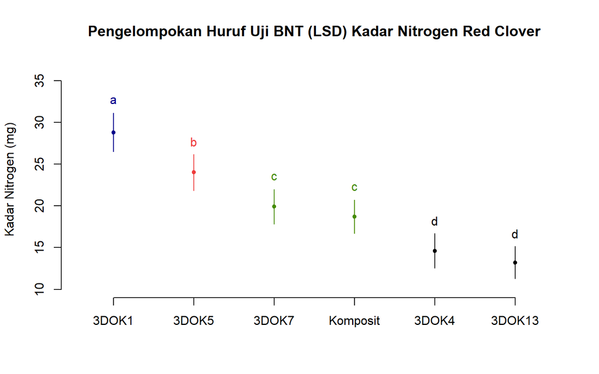

```r
# Visualisasi huruf pengelompokan hasil Uji BNT
plot(uji_bnt, variation = "SD",
     main = "Pengelompokan Huruf Uji BNT (LSD) Kadar Nitrogen Red Clover",
     ylab = "Kadar Nitrogen (mg)")
```

```r
# Langkah 3: Demonstrasi Uji BNT untuk Ulangan Tidak Sama (misal pot baris ke-1 & ke-7 rusak)
df_clover_unequal <- df_clover[-c(1, 7), ]
table(df_clover_unequal$Perlakuan) # Mengecek ulangan tersisa per perlakuan
```

```
#>
#>    3DOK1    3DOK5    3DOK4    3DOK7   3DOK13 Komposit
#>        4        4        5        5        5        5
```

```r
model_ral_unequal <- aov(Kadar_N ~ Perlakuan, data = df_clover_unequal)
uji_bnt_unequal   <- LSD.test(model_ral_unequal, "Perlakuan", alpha = 0.05, console = TRUE)
```

```
#>
#> Study: model_ral_unequal ~ "Perlakuan"
#>
#> LSD t Test for Kadar_N
#>
#> Mean Square Error:  4.077273
#>
#> Perlakuan,  means and individual ( 95 %) CI
#>
#>          Kadar_N      std r        se      LCL      UCL  Min  Max   Q25  Q50
#> 3DOK1      29.65 1.500000 4 1.0096129 27.55619 31.74381 27.6 31.2 29.25 29.9
#> 3DOK13     13.20 1.933908 5 0.9030252 11.32724 15.07276 10.8 15.8 12.00 13.2
#> 3DOK4      14.60 2.073644 5 0.9030252 12.72724 16.47276 11.8 17.2 13.40 15.0
#> 3DOK5      23.75 2.418677 4 1.0096129 21.65619 25.84381 21.2 26.8 22.25 23.5
#> 3DOK7      19.90 2.076054 5 0.9030252 18.02724 21.77276 17.4 22.8 18.80 19.5
#> Komposit   18.70 2.000000 5 0.9030252 16.82724 20.57276 16.2 21.4 17.60 18.5
#>           Q75
#> 3DOK1    30.3
#> 3DOK13   14.2
#> 3DOK4    15.6
#> 3DOK5    25.0
#> 3DOK7    21.0
#> Komposit 19.8
#>
#> Alpha: 0.05 ; DF Error: 22
#> Critical Value of t: 2.073873
#>
#> Groups according to probability of means differences and alpha level( 0.05 )
#>
#> Treatments with the same letter are not significantly different.
#>
#>          Kadar_N groups
#> 3DOK1      29.65      a
#> 3DOK5      23.75      b
#> 3DOK7      19.90      c
#> Komposit   18.70      c
#> 3DOK4      14.60      d
#> 3DOK13     13.20      d
```

```r
# Menghitung nilai kritis spesifik BNT untuk tiap kombinasi jumlah ulangan (4 vs 4, 4 vs 5, 5 vs 5)
ktg_un <- summary(model_ral_unequal)[[1]]["Residuals", "Mean Sq"]
dbg_un <- df.residual(model_ral_unequal)
t_kris <- qt(0.975, df = dbg_un)

cat(sprintf("BNT(r=4 vs r=4) = %.2f mg | BNT(r=4 vs r=5) = %.2f mg | BNT(r=5 vs r=5) = %.2f mg\n",
            t_kris * sqrt(ktg_un * (1/4 + 1/4)),
            t_kris * sqrt(ktg_un * (1/4 + 1/5)),
            t_kris * sqrt(ktg_un * (1/5 + 1/5))))
```

```
#> BNT(r=4 vs r=4) = 2.96 mg | BNT(r=4 vs r=5) = 2.81 mg | BNT(r=5 vs r=5) = 2.65 mg
```

## 2.5 Cara Membaca Output R & Kesimpulan Kasus

**Panduan Membaca Output `LSD.test()`:**

1. **Pada Kasus Ulangan Sama ($r = 5$)**:
   - Nilai `Mean Square Error = 4.391667`, `DF Error = 24`, dan `Critical Value of t = 2.063899`.
   - Diperoleh nilai kritis tunggal **`least Significant Difference = 2.7355` mg** ($\approx 2,74\text{ mg}$). Artinya, setiap pasangan strain yang selisih rata-ratanya melampaui $2,74\text{ mg}$ dinyatakan berbeda nyata pada $\alpha = 5\%$.
   - **Cara Membaca Kolom Huruf (`groups`)**: Perlakuan diurutkan otomatis dari rata-rata tertinggi ke terendah: `3DOK1` ($28,8\text{ a}$), `3DOK5` ($24,0\text{ b}$), `3DOK7` ($19,9\text{ c}$), `Komposit` ($18,7\text{ c}$), `3DOK4` ($14,6\text{ d}$), dan `3DOK13` ($13,2\text{ d}$). **Dua perlakuan yang diikuti huruf yang sama tidak berbeda nyata** (contoh: selisih `3DOK7` dan `Komposit` hanya $|19,9 - 18,7| = 1,20 < 2,74\text{ mg}$ sehingga keduanya berbagi huruf `c`).
2. **Pada Kasus Ulangan Tidak Sama ($r_i \neq r_j$)**:
   - Perhatikan bahwa baris `least Significant Difference` tunggal **tidak lagi dicetak oleh R**, karena nilai kritis BNT kini berbeda tergantung ukuran ulangan pasangan yang dibandingkan: **`2.96` mg** untuk membandingkan sesama $r = 4$ (`3DOK1` vs `3DOK5`), **`2.81` mg** untuk $r = 4$ vs $r = 5$, dan **`2.65` mg** untuk sesama $r = 5$! Semakin sedikit ulangannya, semakin lebar ambang BNT yang harus dilampaui.

**Kalimat Kesimpulan Siap Kutip:** > *“Berdasarkan uji lanjut BNT pada taraf nyata $\alpha = 5\%$ ($\text{BNT}_{0,05} = 2,74\text{ mg}$), inokulasi strain `3DOK1` menghasilkan rata-rata kadar nitrogen tertinggi sebesar $28,80\text{ mg}$ yang berbeda nyata lebih unggul dibandingkan seluruh strain lainnya, diikuti oleh `3DOK5` ($24,00\text{ mg}$), kelompok menengah `3DOK7` ($19,90\text{ mg}$) dan `Komposit` ($18,70\text{ mg}$) yang saling tidak berbeda nyata, serta kelompok terendah `3DOK4` ($14,60\text{ mg}$) dan `3DOK13` ($13,20\text{ mg}$).”*

# 3 Analisis 2.2: Uji Beda Nyata Jujur (BNJ / Tukey’s HSD)

## 3.1 Penjelasan Awal (Konsep Dasar)

**Konsep Dasar — Uji BNJ (*Tukey’s Honestly Significant Difference*):**

Untuk mengatasi kelemahan Uji BNT yang membengkakkan peluang salah Tipe I saat jumlah perlakuan banyak, J.W. Tukey merancang **Uji Beda Nyata Jujur (BNJ / HSD)** berbasis sebaran **Wilayah Sebaran Student (*Studentized Range*, $q$)** yang mengukur selisih antara nilai maksimum dan nilai minimum dari $t$ peubah acak normal. Dengan memakai satu nilai kritis $w = \text{BNJ}_\alpha$, peluang terjadinya salah positif pada **seluruh keluarga perbandingan sekaligus (*family-wise error rate*)** dijaga ketat maksimal sebesar $\alpha$.

## 3.2 Konteks Kasus & Kapan Menggunakan Analisis Ini

**Kapan Memilih Uji BNJ / Tukey HSD?**

- Gunakan **Uji BNJ** apabila **jumlah perlakuan lebih dari 3 ($t > 3$)**, Anda ingin membandingkan **seluruh pasangan rata-rata perlakuan**, dan Anda memprioritaskan **kehati-hatian tinggi (*konservatif*)** agar tidak telanjur merekomendasikan perlakuan yang sebenarnya tidak berbeda (misalnya dalam uji pelepasan varietas unggul nasional atau uji efikasi pupuk/pestisida komersial).
- Kita terapkan Uji BNJ pada dataset **6 strain *Rhizobium* tanaman *Red Clover*** (`model_ral`) dengan dua cara di R: fungsi bawaan `TukeyHSD()` untuk melihat selang kepercayaan selisih pasangan, serta `agricolae::HSD.test()` untuk mendapatkan nilai kritis $\text{BNJ}_{0,05}$ dan huruf notasi.

## 3.3 Model Rumus Nilai Kritis & Hipotesis

Untuk seluruh $\binom{t}{2}$ pasangan nilai tengah populasi:

$$H_0 : \mu_i = \mu_j \quad \text{lawan} \quad H_1 : \mu_i \neq \mu_j \quad (\forall\, i \neq j)$$

Rumus pembanding kritis $\text{BNJ}_\alpha$ (ulangan sama $r$) dan perluasan Tukey-Kramer (ulangan tidak sama):

$$\text{BNJ}_\alpha = w = q_{\alpha;\; t,\; \text{db}_g} \sqrt{\frac{\text{KTG}}{r}}, \qquad w_{(i,j)} = \frac{q_{\alpha;\; t,\; \text{db}_g}}{\sqrt{2}} \sqrt{\text{KTG}\left(\frac{1}{r_i} + \frac{1}{r_j}\right)}$$

di mana $q_{\alpha;\; t,\; \text{db}_g}$ adalah nilai kuantil sebaran *Studentized Range* untuk $t$ perlakuan total dan derajat bebas galat $\text{db}_g$.

## 3.4 Kode R Siap Pakai (Step-by-Step)

```r
# Cara 1: Menampilkan selisih pasangan, selang kepercayaan 95% (lwr..upr), & p-value terkoreksi
tukey_ci <- TukeyHSD(model_ral, "Perlakuan", conf.level = 0.95)
print(tukey_ci)
```

```
#>   Tukey multiple comparisons of means
#>     95% family-wise confidence level
#>
#> Fit: aov(formula = Kadar_N ~ Perlakuan, data = df_clover)
#>
#> $Perlakuan
#>                  diff           lwr           upr     p adj
#> 3DOK5-3DOK1      -4.8  -8.898023854  -0.701976146 0.0151962
#> 3DOK4-3DOK1     -14.2 -18.298023854 -10.101976146 0.0000000
#> 3DOK7-3DOK1      -8.9 -12.998023854  -4.801976146 0.0000083
#> 3DOK13-3DOK1    -15.6 -19.698023854 -11.501976146 0.0000000
#> Komposit-3DOK1  -10.1 -14.198023854  -6.001976146 0.0000010
#> 3DOK4-3DOK5      -9.4 -13.498023854  -5.301976146 0.0000034
#> 3DOK7-3DOK5      -4.1  -8.198023854  -0.001976146 0.0498398
#> 3DOK13-3DOK5    -10.8 -14.898023854  -6.701976146 0.0000003
#> Komposit-3DOK5   -5.3  -9.398023854  -1.201976146 0.0062138
#> 3DOK7-3DOK4       5.3   1.201976146   9.398023854 0.0062138
#> 3DOK13-3DOK4     -1.4  -5.498023854   2.698023854 0.8935716
#> Komposit-3DOK4    4.1   0.001976146   8.198023854 0.0498398
#> 3DOK13-3DOK7     -6.7 -10.798023854  -2.601976146 0.0004650
#> Komposit-3DOK7   -1.2  -5.298023854   2.898023854 0.9413401
#> Komposit-3DOK13   5.5   1.401976146   9.598023854 0.0043149
```

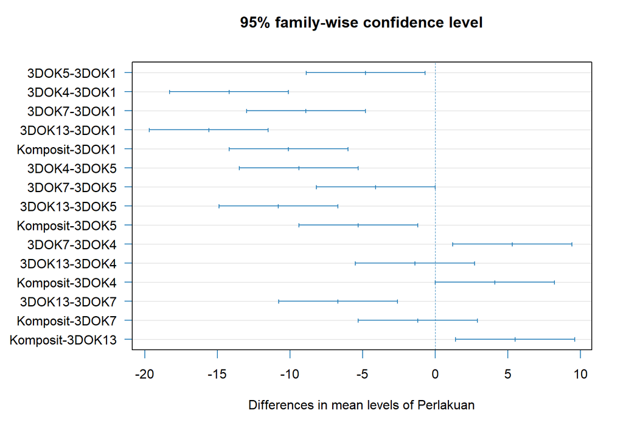

Figure 3.1: Selang kepercayaan simultan 95% Tukey HSD untuk seluruh 15 pasangan perbandingan strain Rhizobium.

```r
# Visualisasi selang kepercayaan 95% selisih pasangan (garis vertikal putus-putus = 0)
par(mar = c(5, 8.5, 4, 2))
plot(tukey_ci, las = 1, col = "#2980b9")
```

```r
par(mar = c(5, 4, 4, 2) + 0.1)

# Cara 2: Menampilkan nilai kritis tunggal BNJ (MSD) & tabel huruf notasi
uji_bnj <- HSD.test(model_ral, "Perlakuan", alpha = 0.05, console = TRUE)
```

```
#>
#> Study: model_ral ~ "Perlakuan"
#>
#> HSD Test for Kadar_N
#>
#> Mean Square Error:  4.391667
#>
#> Perlakuan,  means
#>
#>          Kadar_N      std r        se  Min  Max  Q25  Q50  Q75
#> 3DOK1       28.8 2.302173 5 0.9371944 25.4 31.2 27.6 29.8 30.0
#> 3DOK13      13.2 1.933908 5 0.9371944 10.8 15.8 12.0 13.2 14.2
#> 3DOK4       14.6 2.073644 5 0.9371944 11.8 17.2 13.4 15.0 15.6
#> 3DOK5       24.0 2.167948 5 0.9371944 21.2 26.8 22.6 24.4 25.0
#> 3DOK7       19.9 2.076054 5 0.9371944 17.4 22.8 18.8 19.5 21.0
#> Komposit    18.7 2.000000 5 0.9371944 16.2 21.4 17.6 18.5 19.8
#>
#> Alpha: 0.05 ; DF Error: 24
#> Critical Value of Studentized Range: 4.372651
#>
#> Minimun Significant Difference: 4.098024
#>
#> Treatments with the same letter are not significantly different.
#>
#>          Kadar_N groups
#> 3DOK1       28.8      a
#> 3DOK5       24.0      b
#> 3DOK7       19.9      c
#> Komposit    18.7      c
#> 3DOK4       14.6      d
#> 3DOK13      13.2      d
```

## 3.5 Cara Membaca Output R & Kesimpulan Kasus

**Panduan Membaca Output `TukeyHSD()` dan `HSD.test()`:**

1. **Nilai Kritis BNJ (`Minimun Significant Difference`)**:
   - Dengan kuantil $q_{0,05(6, 24)} = 4,3727$, diperoleh **`MSD = 4.0980` mg** ($\approx 4,10\text{ mg}$).
   - Bandingkan dengan BNT sebelumnya ($2,74\text{ mg}$): ambang BNJ **lebih lebar $1,36\text{ mg}$** karena BNJ menjaga tingkat kepercayaan gabungan 95% untuk seluruh 15 pasangan sekaligus!
2. **Membaca Tabel & Grafik `TukeyHSD()`**:
   - Setiap baris pasangan yang **selang kepercayaannya (`lwr` s.d. `upr`) TIDAK melintasi angka `0`** memiliki `p adj < 0.05` (berbeda nyata).
   - Sebaliknya, hanya ada **dua pasangan yang melintasi garis vertikal `0`**, yaitu `3DOK13-3DOK4` (`diff = -1.4`, `p adj = 0.8936`) dan `Komposit-3DOK7` (`diff = -1.2`, `p adj = 0.9413`). Perhatikan pasangan `3DOK7-3DOK5` dan `Komposit-3DOK4` yang memiliki selisih mutlak tepat `4.10` mg (`p adj = 0.0498 < 0.05`), tepat melampaui ambang kritis `4.098` mg!

**Kalimat Kesimpulan Siap Kutip:** > *“Berdasarkan uji lanjut Beda Nyata Jujur (Tukey HSD) pada taraf nyata $\alpha = 5\%$ ($\text{BNJ}_{0,05} = 4,10\text{ mg}$), strain `3DOK1` ($28,80\text{ mg}$, huruf `a`) memberikan serapan nitrogen tertinggi yang berbeda nyata terhadap kelima perlakuan lainnya, sedangkan `3DOK4` ($14,60\text{ mg}$) dan `3DOK13` ($13,20\text{ mg}$) menempati kelompok terendah (huruf `d`).”*

# 4 Analisis 2.3: Uji Jarak Berganda Duncan (DMRT)

## 4.1 Penjelasan Awal (Konsep Dasar)

**Konsep Dasar — Mengapa Duncan Memakai Nilai Kritis Bertingkat ($R_p$)?**

Jika BNT terlalu longgar dan BNJ terkadang dirasa terlalu kaku saat jumlah perlakuan besar, **Uji Jarak Berganda Duncan (*Duncan’s New Multiple Range Test* / DMRT)** mengambil jalan tengah yang sangat cerdas: setelah rata-rata perlakuan diurutkan, **pasangan rata-rata yang letaknya bersebelahan ($p = 2$) diuji dengan ambang yang kecil**, sedangkan **pasangan rata-rata yang jarak urutannya berjauhan ($p = 3, 4, \dots, t$) diuji dengan ambang $R_p$ yang semakin besar**!

## 4.2 Konteks Kasus & Kapan Menggunakan Analisis Ini

**Kapan Memilih Uji Duncan / DMRT?**

- Gunakan **DMRT** apabila **jumlah perlakuan cukup banyak ($t > 3$)** pada percobaan agronomi, pemuliaan tanaman, atau nutrisi ternak, di mana peneliti menginginkan **sensitivitas (daya pisah) yang lebih tinggi** dibandingkan BNJ untuk menyaring kandidat perlakuan potensial tanpa selonggar BNT.
- Kita terapkan DMRT pada dataset **6 strain *Rhizobium* tanaman *Red Clover*** (`model_ral`).

## 4.3 Model Rumus Nilai Kritis Bertingkat & Hipotesis

Untuk dua rata-rata perlakuan terurut yang mencakup rentang sebanyak $p$ buah nilai tengah ($p = 2, 3, \dots, t$):

$$H_0 : \mu_{(i)} = \mu_{(j)} \quad \text{lawan} \quad H_1 : \mu_{(i)} \neq \mu_{(j)}$$

Tingkat salah Tipe I proteksi Duncan pada rentang $p$ adalah $\alpha_p = 1 - (1 - \alpha)^{p - 1}$, dengan **Jarak Nyata Terkecil Duncan ($R_p$)**:

$$R_p = r_{\alpha;\; p,\; \text{db}_g} \sqrt{\frac{\text{KTG}}{r}}, \qquad p = 2, 3, \dots, t$$

di mana $r_{\alpha;\; p,\; \text{db}_g}$ adalah nilai kritis tabel wilayah berganda Duncan. Khusus untuk $p = 2$ (dua perlakuan bersebelahan), nilai $R_2$ sama persis dengan nilai $\text{BNT}_\alpha$!

## 4.4 Kode R Siap Pakai (Step-by-Step)

```r
# Menjalankan Uji Jarak Berganda Duncan (DMRT) pada alpha = 5%
uji_duncan <- duncan.test(model_ral, "Perlakuan", alpha = 0.05, console = TRUE)
```

```
#>
#> Study: model_ral ~ "Perlakuan"
#>
#> Duncan's new multiple range test
#> for Kadar_N
#>
#> Mean Square Error:  4.391667
#>
#> Perlakuan,  means
#>
#>          Kadar_N      std r        se  Min  Max  Q25  Q50  Q75
#> 3DOK1       28.8 2.302173 5 0.9371944 25.4 31.2 27.6 29.8 30.0
#> 3DOK13      13.2 1.933908 5 0.9371944 10.8 15.8 12.0 13.2 14.2
#> 3DOK4       14.6 2.073644 5 0.9371944 11.8 17.2 13.4 15.0 15.6
#> 3DOK5       24.0 2.167948 5 0.9371944 21.2 26.8 22.6 24.4 25.0
#> 3DOK7       19.9 2.076054 5 0.9371944 17.4 22.8 18.8 19.5 21.0
#> Komposit    18.7 2.000000 5 0.9371944 16.2 21.4 17.6 18.5 19.8
#>
#> Alpha: 0.05 ; DF Error: 24
#>
#> Critical Range
#>        2        3        4        5        6
#> 2.735477 2.873073 2.961416 3.023815 3.070394
#>
#> Means with the same letter are not significantly different.
#>
#>          Kadar_N groups
#> 3DOK1       28.8      a
#> 3DOK5       24.0      b
#> 3DOK7       19.9      c
#> Komposit    18.7      c
#> 3DOK4       14.6      d
#> 3DOK13      13.2      d
```

```r
# Menampilkan secara eksplisit tabel nilai kritis bertingkat Rp untuk jarak peringkat p = 2..6
uji_duncan$duncan
```

```
#>      Table CriticalRange
#> 2 2.918793      2.735477
#> 3 3.065610      2.873073
#> 4 3.159874      2.961416
#> 5 3.226454      3.023815
#> 6 3.276155      3.070394
```

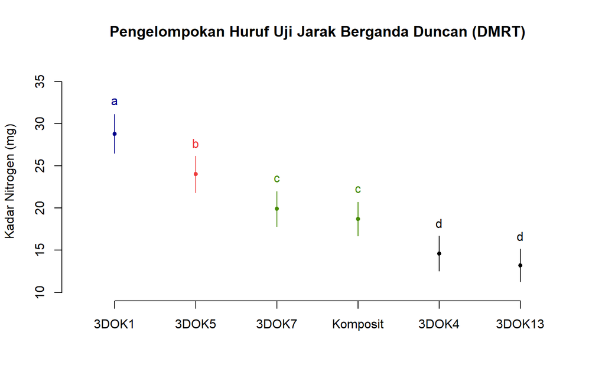

Figure 4.1: Pengelompokan huruf hasil Uji Jarak Berganda Duncan (DMRT) pada kadar nitrogen Red Clover.

```r
# Visualisasi barplot dengan huruf notasi DMRT
plot(uji_duncan, variation = "SD",
     main = "Pengelompokan Huruf Uji Jarak Berganda Duncan (DMRT)",
     ylab = "Kadar Nitrogen (mg)")
```

## 4.5 Cara Membaca Output R & Kesimpulan Kasus

**Panduan Membaca Output `duncan.test()`:**

1. **Tabel `Critical Range` Bertingkat ($R_2$ s.d. $R_6$)**:
   - Untuk membandingkan 2 rata-rata bersebelahan ($p = 2$, misal `3DOK1` vs `3DOK5`), nilai kritisnya adalah **`R_2 = 2.7355` mg** (identik dengan BNT!).
   - Untuk rentang 3 rata-rata ($p = 3$): **`R_3 = 2.8731` mg**; $p = 4$: **`R_4 = 2.9614` mg**; $p = 5$: **`R_5 = 3.0238` mg**; dan untuk rentang terjauh dari peringkat ke-1 hingga ke-6 ($p = 6$, yaitu `3DOK1` vs `3DOK13`): **`R_6 = 3.0704` mg**.
   - Perhatikan bahwa bahkan pada jarak terjauh sekalipun ($R_6 = 3,07\text{ mg}$), nilai kritis Duncan masih lebih kecil (lebih peka) daripada nilai kritis BNJ Tukey ($4,10\text{ mg}$).
2. **Hasil Pengelompokan Huruf**: Keenam perlakuan terbagi tegas menjadi empat kelompok mutu: `a` (`3DOK1`), `b` (`3DOK5`), `c` (`3DOK7` dan `Komposit`), serta `d` (`3DOK4` dan `3DOK13`).

**Kalimat Kesimpulan Siap Kutip:** > *“Berdasarkan Uji Jarak Berganda Duncan (DMRT) pada taraf nyata $\alpha = 5\%$ dengan rentang kritis $R_2 = 2,74\text{ mg}$ hingga $R_6 = 3,07\text{ mg}$, inokulasi strain `3DOK1` ($28,80\text{ mg}$) berbeda nyata melampaui seluruh perlakuan lainnya, sementara strain `3DOK7` ($19,90\text{ mg}$) tidak berbeda nyata dengan kultur standar `Komposit` ($18,70\text{ mg}$).”*

# 5 Analisis 2.4: Uji Lanjut Tak Terencana Lainnya — SNK, Dunnett, & Scheffe

## 5.1 Penjelasan Awal (Konsep Dasar)

**Konsep Dasar — Tiga Uji Spesifik (SNK, Dunnett, & Scheffe):**

1. **Uji *Student-Newman-Keuls* (SNK)**: Bekerja secara bertingkat dari jarak peringkat $p = 2, 3, \dots, t$ persis seperti Duncan, tetapi menggunakan kuantil *Studentized Range* Tukey $q_{\alpha;\; p,\; \text{db}_g}$ pada setiap jenjang $p$, sehingga tingkat proteksinya berada tepat di antara Duncan dan BNJ.
2. **Uji Dunnett**: Dirancang khusus untuk percobaan yang memiliki **satu perlakuan Kontrol/Standar ($K$)**. Alih-alih menguji seluruh $\binom{t}{2}$ pasangan, Dunnett **hanya menguji $(t - 1)$ pasangan** antara tiap perlakuan kandidat melawan Kontrol, sehingga nilai kritisnya jauh lebih hemat/tajam daripada BNJ!
3. **Uji Scheffe**: Menggunakan sebaran $F$ untuk melindungi tingkat kesalahan Tipe I terhadap **segala kemungkinan kontras linier tak terbatas** yang baru digagas setelah peneliti melihat pola angka rata-rata (*post-hoc data snooping*).

## 5.2 Konteks Kasus & Kapan Menggunakan Analisis Ini

**Kriteria Praktis Memilih SNK vs Dunnett vs Scheffe:**

- Pilih **SNK** bila menginginkan prosedur bertahap namun lebih ketat dari DMRT.
- Pilih **Uji Dunnett** bila pertanyaan riset Anda murni berbunyi: *“Strain murni mana saja (`3DOK1`..`3DOK13`) yang mampu mengalahkan atau lebih buruk dibandingkan kultur campuran komersial **`Komposit`** sebagai Kontrol?”*
- Pilih **Uji Scheffe** hanya jika setelah melihat data Anda ingin menguji perbandingan gabungan tak terencana (misal rata-rata 2 strain terbaik vs rata-rata 3 strain lainnya).

## 5.3 Model Rumus Nilai Kritis & Hipotesis

1. **Nilai Kritis Bertingkat SNK**:
   $$W_p = q_{\alpha;\; p,\; \text{db}_g} \sqrt{\frac{\text{KTG}}{r}}, \qquad p = 2, 3, \dots, t$$
2. **Hipotesis & Nilai Kritis Uji Dunnett** (dengan perlakuan ke-$0$ sebagai Kontrol):
   $$H_0 : \mu_i = \mu_0 \quad \text{lawan} \quad H_1 : \mu_i \neq \mu_0 \quad (i = 1, 2, \dots, t - 1)$$
   $$D_\alpha = d_{\alpha;\; t-1,\; \text{db}_g} \sqrt{\frac{2 \cdot \text{KTG}}{r}}$$
3. **Nilai Kritis Uji Scheffe** (untuk perbandingan pasangan rata-rata):
   $$S_\alpha = \sqrt{(t - 1) F_{\alpha;\; t-1,\; \text{db}_g}} \sqrt{\frac{2 \cdot \text{KTG}}{r}}$$

## 5.4 Kode R Siap Pakai (Step-by-Step)

```r
library(multcomp)

# 1. Uji Student-Newman-Keuls (SNK)
uji_snk <- SNK.test(model_ral, "Perlakuan", alpha = 0.05, console = TRUE)
```

```
#>
#> Study: model_ral ~ "Perlakuan"
#>
#> Student Newman Keuls Test
#> for Kadar_N
#>
#> Mean Square Error:  4.391667
#>
#> Perlakuan,  means
#>
#>          Kadar_N      std r        se  Min  Max  Q25  Q50  Q75
#> 3DOK1       28.8 2.302173 5 0.9371944 25.4 31.2 27.6 29.8 30.0
#> 3DOK13      13.2 1.933908 5 0.9371944 10.8 15.8 12.0 13.2 14.2
#> 3DOK4       14.6 2.073644 5 0.9371944 11.8 17.2 13.4 15.0 15.6
#> 3DOK5       24.0 2.167948 5 0.9371944 21.2 26.8 22.6 24.4 25.0
#> 3DOK7       19.9 2.076054 5 0.9371944 17.4 22.8 18.8 19.5 21.0
#> Komposit    18.7 2.000000 5 0.9371944 16.2 21.4 17.6 18.5 19.8
#>
#> Alpha: 0.05 ; DF Error: 24
#>
#> Critical Range
#>        2        3        4        5        6
#> 2.735477 3.309887 3.656241 3.904646 4.098024
#>
#> Means with the same letter are not significantly different.
#>
#>          Kadar_N groups
#> 3DOK1       28.8      a
#> 3DOK5       24.0      b
#> 3DOK7       19.9      c
#> Komposit    18.7      c
#> 3DOK4       14.6      d
#> 3DOK13      13.2      d
```

```r
# 2. Uji Scheffe (paling konservatif)
uji_scheffe <- scheffe.test(model_ral, "Perlakuan", alpha = 0.05, console = TRUE)
```

```
#>
#> Study: model_ral ~ "Perlakuan"
#>
#> Scheffe Test for Kadar_N
#>
#> Mean Square Error  : 4.391667
#>
#> Perlakuan,  means
#>
#>          Kadar_N      std r        se  Min  Max  Q25  Q50  Q75
#> 3DOK1       28.8 2.302173 5 0.9371944 25.4 31.2 27.6 29.8 30.0
#> 3DOK13      13.2 1.933908 5 0.9371944 10.8 15.8 12.0 13.2 14.2
#> 3DOK4       14.6 2.073644 5 0.9371944 11.8 17.2 13.4 15.0 15.6
#> 3DOK5       24.0 2.167948 5 0.9371944 21.2 26.8 22.6 24.4 25.0
#> 3DOK7       19.9 2.076054 5 0.9371944 17.4 22.8 18.8 19.5 21.0
#> Komposit    18.7 2.000000 5 0.9371944 16.2 21.4 17.6 18.5 19.8
#>
#> Alpha: 0.05 ; DF Error: 24
#> Critical Value of F: 2.620654
#>
#> Minimum Significant Difference: 4.797716
#>
#> Means with the same letter are not significantly different.
#>
#>          Kadar_N groups
#> 3DOK1       28.8      a
#> 3DOK5       24.0      b
#> 3DOK7       19.9     bc
#> Komposit    18.7     cd
#> 3DOK4       14.6     de
#> 3DOK13      13.2      e
```

```r
# 3. Uji Dunnett: Menjadikan perlakuan "Komposit" sebagai grup Kontrol acuan (ref)
df_clover$Perlakuan_Dunnett <- relevel(df_clover$Perlakuan, ref = "Komposit")
model_dunnett <- aov(Kadar_N ~ Perlakuan_Dunnett, data = df_clover)

uji_dunnett <- glht(model_dunnett, linfct = mcp(Perlakuan_Dunnett = "Dunnett"))
summary(uji_dunnett)              # Statistik uji-t Dunnett dan p-value terkoreksi
```

```
#>
#>   Simultaneous Tests for General Linear Hypotheses
#>
#> Multiple Comparisons of Means: Dunnett Contrasts
#>
#>
#> Fit: aov(formula = Kadar_N ~ Perlakuan_Dunnett, data = df_clover)
#>
#> Linear Hypotheses:
#>                        Estimate Std. Error t value Pr(>|t|)
#> 3DOK1 - Komposit == 0    10.100      1.325   7.620  < 0.001 ***
#> 3DOK5 - Komposit == 0     5.300      1.325   3.999  0.00242 **
#> 3DOK4 - Komposit == 0    -4.100      1.325  -3.093  0.02062 *
#> 3DOK7 - Komposit == 0     1.200      1.325   0.905  0.83175
#> 3DOK13 - Komposit == 0   -5.500      1.325  -4.150  0.00159 **
#> ---
#> Signif. codes:  0 '***' 0.001 '**' 0.01 '*' 0.05 '.' 0.1 ' ' 1
#> (Adjusted p values reported -- single-step method)
```

```r
confint(uji_dunnett, level = 0.95) # Selang kepercayaan simultan 95% terhadap Kontrol
```

```
#>
#>   Simultaneous Confidence Intervals
#>
#> Multiple Comparisons of Means: Dunnett Contrasts
#>
#>
#> Fit: aov(formula = Kadar_N ~ Perlakuan_Dunnett, data = df_clover)
#>
#> Quantile = 2.6959
#> 95% family-wise confidence level
#>
#>
#> Linear Hypotheses:
#>                        Estimate lwr     upr
#> 3DOK1 - Komposit == 0  10.1000   6.5269 13.6731
#> 3DOK5 - Komposit == 0   5.3000   1.7269  8.8731
#> 3DOK4 - Komposit == 0  -4.1000  -7.6731 -0.5269
#> 3DOK7 - Komposit == 0   1.2000  -2.3731  4.7731
#> 3DOK13 - Komposit == 0 -5.5000  -9.0731 -1.9269
```

## 5.5 Cara Membaca Output R & Kesimpulan Kasus

**Kalimat Kesimpulan Siap Kutip (Uji Dunnett):** > *“Berdasarkan Uji Dunnett pada taraf nyata $\alpha = 5\%$ terhadap kultur standar `Komposit` ($18,70\text{ mg}$), hanya strain `3DOK1` ($+10,10\text{ mg}$; $p < 0,001$) dan `3DOK5` ($+5,30\text{ mg}$; $p = 0,0024$) yang mampu meningkatkan kadar nitrogen tanaman Red Clover secara nyata melampaui kontrol.”*

# 6 Analisis 2.5: Uji Terencana — Metode Kontras Ortogonal (Ulangan Sama & Tidak Sama)

## 6.1 Penjelasan Awal (Konsep Dasar)

**Konsep Dasar — Memecah Habis JK Perlakuan dengan Kontras Ortogonal:**

Apabila perlakuan kualitatif memiliki **pengelompokan logis yang sudah direncanakan sejak proposal penelitian (*a priori*)**, kita tidak perlu membandingkan semua pasangan secara membabi-buta. **Kontras** adalah kombinasi linier untuk membandingkan dua kelompok perlakuan (misalnya *Kelompok Pupuk Organik vs Pupuk Anorganik*, atau *Pakan Lokal vs Pakan Impor*).

Dua kontras disebut **saling ortogonal (bebas informasi)** apabila koefisien pengalinya tegak lurus. Keistimewaan utamanya: jika kita menyusun $(t - 1)$ buah kontras yang saling ortogonal, maka **Jumlah Kuadrat Perlakuan ($\text{JKP}$) berderajat bebas $(t - 1)$ akan terpecah habis tanpa sisa** menjadi $(t - 1)$ komponen Jumlah Kuadrat Kontras yang masing-masing berderajat bebas $1$:
$$\text{JK}_{\text{Perlakuan}} = \text{JK}(C_1) + \text{JK}(C_2) + \dots + \text{JK}(C_{t-1})$$

## 6.2 Konteks Kasus & Kapan Menggunakan Analisis Ini

**Studi Kasus: *Feed Supplement* Ayam Pedaging:**

Gunakan **Kontras Ortogonal** ketika perlakuan bersifat **kualitatif terstruktur**. Studi kasus: Percobaan RAL menguji pengaruh *feed supplement* dari **6 pabrik berbeda** terhadap bobot akhir ayam pedaging (kg) dengan $r = 4$ ulangan (`data/03_ayam_kontras_ral.csv`): * **Pabrik `A` dan `B`**: Produk Dalam Negeri (**Lokal**) * **Pabrik `C` dan `D`**: Produk Impor dari **Eropa** * **Pabrik `E` dan `F`**: Produk Impor dari **Amerika Serikat (AS)**

Lima pertanyaan riset terencana ($\text{db} = 6 - 1 = 5$) yang ingin dijawab adalah: 1. **$C_1$**: Apakah suplemen **Lokal (`A, B`)** berbeda dengan **Impor (`C, D, E, F`)**? 2. **$C_2$**: Di antara produk impor, apakah **Impor Eropa (`C, D`)** berbeda dengan **Impor AS (`E, F`)**? 3. **$C_3$**: Di dalam grup lokal, apakah **Pabrik `A`** berbeda dengan **Pabrik `B`**? 4. **$C_4$**: Di dalam grup Eropa, apakah **Pabrik `C`** berbeda dengan **Pabrik `D`**? 5. **$C_5$**: Di dalam grup AS, apakah **Pabrik `E`** berbeda dengan **Pabrik `F`**?

Selain kasus **Ulangan Sama ($r = 4$)**, kita juga mempraktikkan cara menyusun koefisien kontras ortogonal pada **Ulangan Tidak Sama ($r_i$ berbeda)** jika terdapat satuan percobaan yang hilang!

## 6.3 Model Rumus Kontras Ortogonal & Hipotesis

### 6.3.1 1. Kasus Ulangan Sama ($r_1 = r_2 = \dots = r_t = r$)

Suatu fungsi linier $L_m = \sum_{i=1}^t c_{mi} \bar{Y}_{i\cdot}$ disebut kontras dan dua kontras $(L_1, L_2)$ saling ortogonal jika memenuhi:

$$\text{Syarat Kontras: } \sum_{i=1}^t c_{mi} = 0, \qquad \text{Syarat Ortogonal: } \sum_{i=1}^t c_{1i} c_{2i} = 0$$

Jumlah Kuadrat dan statistik uji $F$ untuk kontras ke-$m$ ($\text{db} = 1$):

$$\text{JK}(C_m) = \frac{r \left(\sum_{i=1}^t c_{mi} \bar{Y}_{i\cdot}\right)^2}{\sum_{i=1}^t c_{mi}^2} = \frac{\left(\sum_{i=1}^t c_{mi} Y_{i\cdot}\right)^2}{r \sum_{i=1}^t c_{mi}^2}, \qquad F_{\text{hitung}(C_m)} = \frac{\text{JK}(C_m) / 1}{\text{KTG}} \sim F_{(\alpha;\; 1,\; \text{db}_g)}$$

### 6.3.2 2. Kasus Ulangan Tidak Sama ($r_i$ berbeda antar-perlakuan)

Apabila ulangan perlakuan ke-$i$ adalah $r_i$ dan kontras dinyatakan dalam total perlakuan $L_m = \sum_{i=1}^t k_{mi} Y_{i\cdot} = \sum_{i=1}^t (r_i k_{mi}) \bar{Y}_{i\cdot}$, maka syarat kontras dan keortogonalan berbobot ulangan yang wajib dipenuhi oleh matriks kolom `contrasts()` di R adalah:

$$\text{Syarat Kontras: } \sum_{i=1}^t r_i k_{mi} = 0, \qquad \text{Syarat Ortogonal Berbobot: } \sum_{i=1}^t r_i k_{1i} k_{2i} = 0, \qquad \text{JK}(C_m) = \frac{\left(\sum_{i=1}^t k_{mi} Y_{i\cdot}\right)^2}{\sum_{i=1}^t r_i k_{mi}^2}$$

*(Tips praktis membandingkan Grup 1 berulangan total $R_1$ melawan Grup 2 berulangan total $R_2$: beri bobot $+R_2$ pada setiap perlakuan di Grup 1 dan $-R_1$ pada setiap perlakuan di Grup 2, maka otomatis $\sum r_i k_i = R_1(+R_2) + R_2(-R_1) = 0$!)*

**Pasangan Hipotesis untuk Kontras ke-$m$ ($m = 1, \dots, 5$):**

- $H_0 : \sum_{i=1}^t c_{mi}\mu_i = 0$ (contoh untuk $C_1$: $\frac{\mu_A + \mu_B}{2} = \frac{\mu_C + \mu_D + \mu_E + \mu_F}{4}$, rata-rata suplemen Lokal sama dengan Impor).
- $H_1 : \sum_{i=1}^t c_{mi}\mu_i \neq 0$ (terdapat perbedaan nyata pada kontras ke-$m$).

## 6.4 Kode R Siap Pakai (Step-by-Step)

```r
# Membaca dataset Feed Supplement Ayam (6 Pabrik x 4 Ulangan)
df_ayam <- read.csv("../data/03_ayam_kontras_ral.csv")
df_ayam$Pabrik <- factor(df_ayam$Pabrik, levels = c("A", "B", "C", "D", "E", "F"))

# Menampilkan rata-rata bobot akhir ayam per pabrik
aggregate(Bobot_Akhir ~ Pabrik, data = df_ayam, mean)
```

```
#>   Pabrik Bobot_Akhir
#> 1      A         5.0
#> 2      B         5.5
#> 3      C         6.5
#> 4      D         6.8
#> 5      E         7.3
#> 6      F         7.2
```

```r
# ==============================================================================
# BAGIAN A: KONTRAS ORTOGONAL ULANGAN SAMA (r = 4)
# ==============================================================================
mat_kontras <- cbind(
  "Lokal vs Impor" = c( 2,  2, -1, -1, -1, -1),
  "Eropa vs AS"    = c( 0,  0,  1,  1, -1, -1),
  "Pabrik A vs B"  = c( 1, -1,  0,  0,  0,  0),
  "Pabrik C vs D"  = c( 0,  0,  1, -1,  0,  0),
  "Pabrik E vs F"  = c( 0,  0,  0,  0,  1, -1)
)

# Verifikasi syarat jumlah koefisien = 0 dan matriks t(C) %*% C berbentuk diagonal
colSums(mat_kontras)
```

```
#> Lokal vs Impor    Eropa vs AS  Pabrik A vs B  Pabrik C vs D  Pabrik E vs F
#>              0              0              0              0              0
```

```r
t(mat_kontras) %*% mat_kontras
```

```
#>                Lokal vs Impor Eropa vs AS Pabrik A vs B Pabrik C vs D
#> Lokal vs Impor             12           0             0             0
#> Eropa vs AS                 0           4             0             0
#> Pabrik A vs B               0           0             2             0
#> Pabrik C vs D               0           0             0             2
#> Pabrik E vs F               0           0             0             0
#>                Pabrik E vs F
#> Lokal vs Impor             0
#> Eropa vs AS                0
#> Pabrik A vs B              0
#> Pabrik C vs D              0
#> Pabrik E vs F              2
```

```r
# Memasang kontras ke faktor Pabrik dan memecah JK Perlakuan dengan argumen 'split'
contrasts(df_ayam$Pabrik) <- mat_kontras
model_ayam <- aov(Bobot_Akhir ~ Pabrik, data = df_ayam)

summary.aov(model_ayam, split = list(Pabrik = list(
  "C1: Lokal (A,B) vs Impor (C,D,E,F)" = 1,
  "C2: Impor Eropa (C,D) vs AS (E,F)"  = 2,
  "C3: Lokal Pabrik A vs Pabrik B"     = 3,
  "C4: Eropa Pabrik C vs Pabrik D"     = 4,
  "C5: AS Pabrik E vs Pabrik F"        = 5
)))
```

```
#>                                              Df Sum Sq Mean Sq F value   Pr(>F)
#> Pabrik                                        5  17.55   3.511  40.508 3.54e-09
#>   Pabrik: C1: Lokal (A,B) vs Impor (C,D,E,F)  1  15.41  15.413 177.846 9.06e-11
#>   Pabrik: C2: Impor Eropa (C,D) vs AS (E,F)   1   1.44   1.440  16.615 0.000709
#>   Pabrik: C3: Lokal Pabrik A vs Pabrik B      1   0.50   0.500   5.769 0.027319
#>   Pabrik: C4: Eropa Pabrik C vs Pabrik D      1   0.18   0.180   2.077 0.166712
#>   Pabrik: C5: AS Pabrik E vs Pabrik F         1   0.02   0.020   0.231 0.636740
#> Residuals                                    18   1.56   0.087
#>
#> Pabrik                                       ***
#>   Pabrik: C1: Lokal (A,B) vs Impor (C,D,E,F) ***
#>   Pabrik: C2: Impor Eropa (C,D) vs AS (E,F)  ***
#>   Pabrik: C3: Lokal Pabrik A vs Pabrik B     *
#>   Pabrik: C4: Eropa Pabrik C vs Pabrik D
#>   Pabrik: C5: AS Pabrik E vs Pabrik F
#> Residuals
#> ---
#> Signif. codes:  0 '***' 0.001 '**' 0.01 '*' 0.05 '.' 0.1 ' ' 1
```

```r
# ==============================================================================
# BAGIAN B: KONTRAS ORTOGONAL ULANGAN TIDAK SAMA (r_i BERBEDA)
# ==============================================================================
# Simulasi: 1 sampel hilang di Pabrik A (baris 1) & 1 sampel hilang di Pabrik D (baris 13)
df_ayam_un <- df_ayam[-c(1, 13), ]
df_ayam_un$Pabrik <- factor(df_ayam_un$Pabrik, levels = c("A", "B", "C", "D", "E", "F"))
r_vec <- as.numeric(table(df_ayam_un$Pabrik)) # Ulangan kini: A=3, B=4, C=4, D=3, E=4, F=4
names(r_vec) <- levels(df_ayam_un$Pabrik)
print(r_vec)
```

```
#> A B C D E F
#> 3 4 4 3 4 4
```

```r
# Menyusun koefisien berbobot k_i sesuai jumlah ulangan grup lawan:
# C1: Lokal (r_A+r_B = 7) vs Impor (r_C+r_D+r_E+r_F = 15) -> (+15, +15, -7, -7, -7, -7)
# C2: Eropa (r_C+r_D = 7) vs AS (r_E+r_F = 8)             -> (  0,   0, +8, +8, -7, -7)
# C3: A (r_A = 3) vs B (r_B = 4)                          -> ( +4,  -3,  0,  0,  0,  0)
# C4: C (r_C = 4) vs D (r_D = 3)                          -> (  0,   0, +3, -4,  0,  0)
# C5: E (r_E = 4) vs F (r_F = 4)                          -> (  0,   0,  0,  0, +1, -1)
mat_kontras_un <- cbind(
  C1 = c(15, 15, -7, -7, -7, -7),
  C2 = c( 0,  0,  8,  8, -7, -7),
  C3 = c( 4, -3,  0,  0,  0,  0),
  C4 = c( 0,  0,  3, -4,  0,  0),
  C5 = c( 0,  0,  0,  0,  1, -1)
)

# Verifikasi syarat sum(r_i * k_i) = 0 dan matriks t(K) %*% diag(r) %*% K diagonal murni!
colSums(r_vec * mat_kontras_un)
```

```
#> C1 C2 C3 C4 C5
#>  0  0  0  0  0
```

```r
t(mat_kontras_un) %*% diag(r_vec) %*% mat_kontras_un
```

```
#>      C1  C2 C3 C4 C5
#> C1 2310   0  0  0  0
#> C2    0 840  0  0  0
#> C3    0   0 84  0  0
#> C4    0   0  0 84  0
#> C5    0   0  0  0  8
```

```r
# Memecah JK Perlakuan pada data tak seimbang tanpa kebocoran jumlah kuadrat sedikit pun
contrasts(df_ayam_un$Pabrik) <- mat_kontras_un
model_ayam_un <- aov(Bobot_Akhir ~ Pabrik, data = df_ayam_un)
summary.aov(model_ayam_un, split = list(Pabrik = list(
  "C1: Lokal vs Impor (Tak Seimbang)" = 1,
  "C2: Eropa vs AS (Tak Seimbang)"    = 2,
  "C3: Pabrik A vs B (r=3 vs r=4)"    = 3,
  "C4: Pabrik C vs D (r=4 vs r=3)"    = 4,
  "C5: Pabrik E vs F (r=4 vs r=4)"    = 5
)))
```

```
#>                                             Df Sum Sq Mean Sq F value   Pr(>F)
#> Pabrik                                       5 14.658   2.932  41.386 1.35e-08
#>   Pabrik: C1: Lokal vs Impor (Tak Seimbang)  1 12.896  12.896 182.067 3.70e-10
#>   Pabrik: C2: Eropa vs AS (Tak Seimbang)     1  1.189   1.189  16.783 0.000842
#>   Pabrik: C3: Pabrik A vs B (r=3 vs r=4)     1  0.230   0.230   3.254 0.090119
#>   Pabrik: C4: Pabrik C vs D (r=4 vs r=3)     1  0.322   0.322   4.545 0.048873
#>   Pabrik: C5: Pabrik E vs F (r=4 vs r=4)     1  0.020   0.020   0.282 0.602463
#> Residuals                                   16  1.133   0.071
#>
#> Pabrik                                      ***
#>   Pabrik: C1: Lokal vs Impor (Tak Seimbang) ***
#>   Pabrik: C2: Eropa vs AS (Tak Seimbang)    ***
#>   Pabrik: C3: Pabrik A vs B (r=3 vs r=4)    .
#>   Pabrik: C4: Pabrik C vs D (r=4 vs r=3)    *
#>   Pabrik: C5: Pabrik E vs F (r=4 vs r=4)
#> Residuals
#> ---
#> Signif. codes:  0 '***' 0.001 '**' 0.01 '*' 0.05 '.' 0.1 ' ' 1
```

## 6.5 Cara Membaca Output R & Kesimpulan Kasus

**Panduan Membaca Dekomposisi Kontras Ortogonal:**

1. **Bukti Partisi Sempurna Jumlah Kuadrat (`Sum Sq`)**:
   - Pada kasus **Ulangan Sama**, `Sum Sq` total faktor `Pabrik` adalah **`17.55`**. Perhatikan penjumlahan kelima komponen kontras di bawahnya:
     $$15,413 + 1,440 + 0,500 + 0,180 + 0,020 = 17,553 \equiv \text{JK}_{\text{Pabrik}}!$$
   - Bahkan menariknya, kontras **`C1 (Lokal vs Impor)` sendirian menyumbang $15,413 / 17,553 = 87,8\%$** dari seluruh keragaman antar-pabrik!
   - Pada kasus **Ulangan Tidak Sama**, berkat pembobotan $r_i$ yang tepat, kelima komponen kontras juga terpecah sempurna ($12,896 + 1,189 + 0,230 + 0,322 + 0,020 = 14,657 \approx 14,658 = \text{JK}_{\text{Pabrik}}$).
2. **Evaluasi Signifikansi Tiap Pertanyaan Riset (Ulangan Sama)**:
   - **`C1` (Lokal vs Impor)**: `F = 177.846`, `Pr(>F) = 9.06e-11 ***` $\rightarrow$ **Sangat nyata!** Suplemen impor ($6,95\text{ kg}$) menghasilkan bobot ayam jauh lebih tinggi daripada suplemen lokal ($5,25\text{ kg}$).
   - **`C2` (Impor Eropa vs Impor AS)**: `F = 16.615`, `Pr(>F) = 0.000709 ***` $\rightarrow$ **Sangat nyata!** Produk impor AS ($7,25\text{ kg}$) lebih unggul dibandingkan impor Eropa ($6,65\text{ kg}$).
   - **`C3` (Lokal A vs Lokal B)**: `F = 5.769`, `Pr(>F) = 0.027319 *` $\rightarrow$ **Nyata pada $\alpha = 5\%$** (`B = 5.50 kg` lebih tinggi dari `A = 5.00 kg`).
   - **`C4` (Eropa C vs D)** & **`C5` (AS E vs F)**: `Pr(>F) = 0.1667` dan `0.6367` (`> 0.05`, tidak nyata) $\rightarrow$ Merek pabrik dari wilayah impor yang sama memiliki kualitas yang setara.

**Kalimat Kesimpulan Siap Kutip:** > *“Penguraian kontras ortogonal menunjukkan bahwa perbedaan bobot akhir ayam pedaging terutama disebabkan oleh keunggulan feed supplement impor dibandingkan produk lokal ($F = 177,85$; $p = 9,06 \times 10^{-11}$) serta keunggulan produk impor Amerika Serikat atas Eropa ($F = 16,62$; $p = 0,0007$). Di antara sesama pabrik lokal, Pabrik B unggul nyata atas Pabrik A ($p = 0,0273$), sedangkan antar-pabrik di dalam kawasan Eropa ($p = 0,1667$) maupun di dalam kawasan AS ($p = 0,6367$) tidak menunjukkan perbedaan nyata.”*

# 7 Analisis 2.6: Uji Terencana — Metode Polinomial Ortogonal

## 7.1 Penjelasan Awal (Konsep Dasar)

**Konsep Dasar — Mengapa Dosis/Jarak Tanam Tidak Tepat Diuji dengan Huruf BNT/Duncan?**

Apabila taraf perlakuan berupa **angka kuantitatif** (seperti dosis pupuk $0, 50, 100, 150\text{ kg/ha}$ atau jarak tanam $18, 24, 30, 36, 42\text{ inci}$), menggunakan uji huruf BNT/Duncan membuat kita kehilangan informasi terpenting, yakni **bentuk pola kurva respons** dan kemampuan menduga nilai tengah di antara taraf yang diuji (misal pada jarak $27\text{ inci}$).

**Metode Polinomial Ortogonal** menguraikan Jumlah Kuadrat Perlakuan berderajat bebas $(t - 1)$ menjadi komponen-komponen derajat kurva yang saling bebas: 1. **Linier** ($\text{db} = 1$): Apakah respon terus naik atau terus turun membentuk garis lurus? 2. **Kuadratik** ($\text{db} = 1$): Apakah respon melengkung membentuk parabola (memiliki titik puncak optimum/minimum)? 3. **Kubik** ($\text{db} = 1$): Apakah respon membentuk gelombang huruf S (dua titik belok)? 4. **Kuartik**, dst. hingga derajat ke-$(t - 1)$.

## 7.2 Konteks Kasus & Kapan Menggunakan Analisis Ini

**Studi Kasus: Jarak Tanam Kedelai *Ottawa Mandarin*:**

- **Kapan Digunakan?** Gunakan **Polinomial Ortogonal** setiap kali faktor perlakuan bersifat **kuantitatif**. Fungsi `contr.poly(t)` di R secara otomatis membangkitkan koefisien polinomial ortogonal untuk $t$ taraf yang **berjarak sama (*equally spaced*)**.
- **Skenario Penelitian**: Suatu percobaan lapangan dalam **Rancangan Acak Kelompok (6 Kelompok)** meneliti pengaruh **5 taraf jarak tanam antar-barisan** yang berjarak sama $d = 6\text{ inci}$ (yaitu **`18`, `24`, `30`, `36`, dan `42` inci**) terhadap **hasil biji kedelai varietas *Ottawa Mandarin* (bushels/acre)**. Dataset tersimpan pada `data/04_kedelai_polinomial_rak.csv`.

## 7.3 Model Rumus Polinomial Ortogonal & Hipotesis

Untuk $t = 5$ taraf kuantitatif $X_1, X_2, \dots, X_5$ yang berjarak sama, model polinomial ortogonal menduga respon rata-rata sebagai kombinasi polinomial ortogonal $P_m(X)$:

$$\mu(X_i) = \alpha_0 + \alpha_1 P_1(X_i) + \alpha_2 P_2(X_i) + \alpha_3 P_3(X_i) + \alpha_4 P_4(X_i)$$

dengan koefisien bilangan bulat baku untuk $t = 5$:

- **Linier ($P_1$)**: $(-2,\; -1,\; 0,\; +1,\; +2)$
- **Kuadratik ($P_2$)**: $(+2,\; -1,\; -2,\; -1,\; +2)$
- **Kubik ($P_3$)**: $(-1,\; +2,\; 0,\; -2,\; +1)$
- **Kuartik ($P_4$)**: $(+1,\; -4,\; +6,\; -4,\; +1)$

*(Catatan: `contr.poly(5)` membagi tiap vektor di atas dengan akar jumlah kuadratnya $\sqrt{\sum P_{mi}^2}$ sehingga ternormalisasi berpanjang satuan, namun menghasilkan nilai `Sum Sq` dan `F value` yang **100% identik**!)*

**Pasangan Hipotesis Berjenjang:**

- **Tren Linier**: $H_0 : \alpha_1 = 0$ vs $H_1 : \alpha_1 \neq 0$
- **Tren Kuadratik**: $H_0 : \alpha_2 = 0$ vs $H_1 : \alpha_2 \neq 0$
- **Tren Kubik**: $H_0 : \alpha_3 = 0$ vs $H_1 : \alpha_3 \neq 0$
- **Tren Kuartik**: $H_0 : \alpha_4 = 0$ vs $H_1 : \alpha_4 \neq 0$

Model kurva yang dipilih adalah **polinomial berderajat tertinggi yang masih nyata secara statistik** (dan komponen simpangan derajat di atasnya tidak nyata).

## 7.4 Kode R Siap Pakai (Step-by-Step)

```r
# Langkah 1: Membaca data dan menyiapkan peubah Jarak sebagai factor (untuk ANOVA) & numeric (untuk kurva)
df_kedelai <- read.csv("../data/04_kedelai_polinomial_rak.csv")
df_kedelai$Jarak_Faktor <- factor(df_kedelai$Jarak_Inci)
df_kedelai$Kelompok     <- factor(df_kedelai$Kelompok)

# Rata-rata hasil kedelai pada masing-masing jarak tanam
rataan_jarak <- aggregate(Hasil ~ Jarak_Inci, data = df_kedelai, mean)
print(rataan_jarak)
```

```
#>   Jarak_Inci    Hasil
#> 1         18 35.15000
#> 2         24 31.63333
#> 3         30 30.16667
#> 4         36 29.53333
#> 5         42 28.15000
```

```r
# Langkah 2: Memasang matriks koefisien Polinomial Ortogonal 5 taraf berjarak sama
round(contr.poly(5), 4)
```

```
#>           .L      .Q      .C      ^4
#> [1,] -0.6325  0.5345 -0.3162  0.1195
#> [2,] -0.3162 -0.2673  0.6325 -0.4781
#> [3,]  0.0000 -0.5345  0.0000  0.7171
#> [4,]  0.3162 -0.2673 -0.6325 -0.4781
#> [5,]  0.6325  0.5345  0.3162  0.1195
```

```r
contrasts(df_kedelai$Jarak_Faktor) <- contr.poly(5)

# Langkah 3: Menjalankan ANOVA RAK dan memecah JK Jarak_Faktor menjadi 4 derajat polinomial
model_poly <- aov(Hasil ~ Kelompok + Jarak_Faktor, data = df_kedelai)
summary.aov(model_poly, split = list(Jarak_Faktor = list(
  "Linier"    = 1,
  "Kuadratik" = 2,
  "Kubik"     = 3,
  "Kuartik"   = 4
)))
```

```
#>                           Df Sum Sq Mean Sq F value   Pr(>F)
#> Kelompok                   5  29.98    6.00   1.888   0.1415
#> Jarak_Faktor               4 171.39   42.85  13.494 1.73e-05 ***
#>   Jarak_Faktor: Linier     1 155.53  155.53  48.979 8.62e-07 ***
#>   Jarak_Faktor: Kuadratik  1  11.15   11.15   3.511   0.0757 .
#>   Jarak_Faktor: Kubik      1   4.70    4.70   1.481   0.2377
#>   Jarak_Faktor: Kuartik    1   0.01    0.01   0.004   0.9526
#> Residuals                 20  63.51    3.18
#> ---
#> Signif. codes:  0 '***' 0.001 '**' 0.01 '*' 0.05 '.' 0.1 ' ' 1
```

```r
# Langkah 4: Menduga persamaan garis respons linier Y_hat = b0 + b1 * Jarak
mod_tren_linier <- lm(Hasil ~ Jarak_Inci, data = df_kedelai)
coef(mod_tren_linier)
```

```
#> (Intercept)  Jarak_Inci
#>  38.9766667  -0.2683333
```

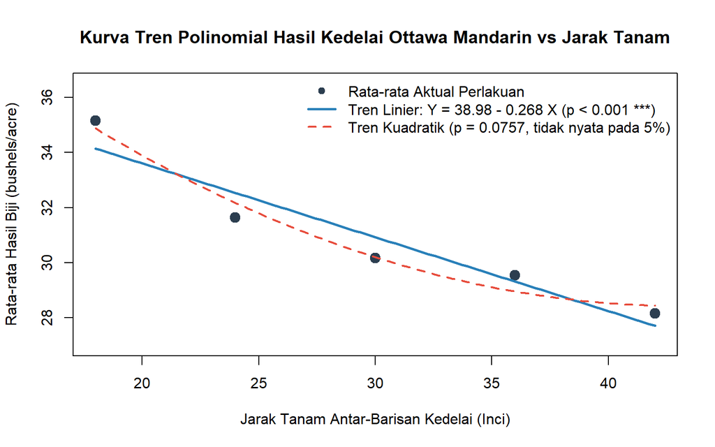

Figure 7.1: Kurva respons tren polinomial hasil kedelai Ottawa Mandarin terhadap peningkatan jarak tanam barisan (18 hingga 42 inci).

```r
# Langkah 5: Visualisasi titik rata-rata aktual bersama garis tren Linier & kurva Kuadratik
jarak_halus <- seq(18, 42, length.out = 100)
plot(rataan_jarak$Jarak_Inci, rataan_jarak$Hasil,
     pch = 19, col = "#2c3e50", cex = 1.5, ylim = c(27, 36.5),
     xlab = "Jarak Tanam Antar-Barisan Kedelai (Inci)",
     ylab = "Rata-rata Hasil Biji (bushels/acre)",
     main = "Kurva Tren Polinomial Hasil Kedelai Ottawa Mandarin vs Jarak Tanam")

lines(jarak_halus,
      predict(mod_tren_linier, newdata = data.frame(Jarak_Inci = jarak_halus)),
      col = "#2980b9", lwd = 2.5)
lines(jarak_halus,
      predict(lm(Hasil ~ poly(Jarak_Inci, 2), data = df_kedelai),
              newdata = data.frame(Jarak_Inci = jarak_halus)),
      col = "#e74c3c", lwd = 2, lty = 2)
legend("topright",
       legend = c("Rata-rata Aktual Perlakuan",
                  "Tren Linier: Y = 38.98 - 0.268 X (p < 0.001 ***)",
                  "Tren Kuadratik (p = 0.0757, tidak nyata pada 5%)"),
       pch = c(19, NA, NA), lty = c(NA, 1, 2), lwd = c(NA, 2.5, 2),
       col = c("#2c3e50", "#2980b9", "#e74c3c"), bty = "n")
```

## 7.5 Cara Membaca Output R & Kesimpulan Kasus

**Panduan Membaca Output Polinomial Ortogonal:**

1. **Pengaruh Umum Jarak Tanam (`Jarak_Faktor`)**:
   - Berpengaruh sangat nyata dengan `Sum Sq = 171.39`, `F value = 13.494`, dan `Pr(>F) = 1.73e-05 ***`.
2. **Dekomposisi Derajat Polinomial**:
   - **Komponen `Linier`**: `Sum Sq = 155.53` (`F = 48.979`, **`Pr(>F) = 8.62e-07 ***`**) $\rightarrow$ **Sangat nyata!** Komponen linier sendirian menjelaskan $155,53 / 171,39 = \mathbf{90,75\%}$ dari seluruh keragaman pengaruh jarak tanam!
   - **Komponen `Kuadratik`**: `Sum Sq = 11.15` (`F = 3.511`, `Pr(>F) = 0.0757 .`) $\rightarrow$ **Tidak nyata pada taraf $\alpha = 5\%$** (hanya mendekati nyata pada $\alpha = 10\%$).
   - **Komponen `Kubik` & `Kuartik`**: `Pr(>F) = 0.2377` dan `0.9526` $\rightarrow$ **Sama sekali tidak nyata**.
   - Cek total partisi JK: $155,53 + 11,15 + 4,70 + 0,01 = 171,39 = \text{JK}_{\text{Jarak}}$!
3. **Interpretasi Persamaan Respons Linier ($\hat{Y} = 38,98 - 0,268 X$)**:
   - Koefisien kemiringan $b_1 = -0,2683$ bermakna bahwa pada rentang jarak tanam $18$ hingga $42\text{ inci}$, **setiap pelebaran jarak tanam sebesar $1\text{ inci}$ menurunkan hasil kedelai rata-rata sebesar $0,268\text{ bushels/acre}$** (atau turun sekitar $1,61\text{ bushels/acre}$ setiap pelebaran $6\text{ inci}$), sehingga jarak tanam paling rapat ($18\text{ inci}$) menghasilkan panen tertinggi ($35,15\text{ bushels/acre}$).

**Kalimat Kesimpulan Siap Kutip:** > *“Analisis polinomial ortogonal menunjukkan bahwa jarak tanam antar-barisan berpengaruh sangat nyata terhadap hasil biji kedelai varietas Ottawa Mandarin ($F = 13,49$; $p = 1,73 \times 10^{-5}$), dengan pola respons yang mengikuti **tren linier menurun sangat nyata** ($F_{\text{linier}} = 48,98$; $p = 8,62 \times 10^{-7}$; menyumbang $90,75\%$ keragaman perlakuan), sedangkan komponen kuadratik ($p = 0,0757$), kubik ($p = 0,2377$), dan kuartik ($p = 0,9526$) tidak nyata pada taraf $\alpha = 5\%$. Hubungan respons dinyatakan melalui persamaan $\hat{Y} = 38,98 - 0,268 X$, di mana jarak tanam tersempit $18\text{ inci}$ memberikan hasil tertinggi sebesar $35,15\text{ bushels/acre}$.”*